# Moore_neighbour_tuto

sginot

12/13/2022

## Introduction

This small tutorial serves to illustrate why, and how to use the Moore Neighbor Tracing algorithm (MNT) using Fiji and R. The MNT is an algorithm which allows to trace contours/lines (in the present case, lines). More detailed information on the algorithm itself can be found [here](https://www.imageprocessingplace.com/downloads_V3/root_downloads/tutorials/contour_tracing_Abeer_George_Ghuneim/moore.html)

In our case, the MNT will be used to trace examples of sutures lines from cephalopod conchs, to allow subsequent morphometric analyses.

## The data

Four low quality images representing suture lines from diverse cephalopods were obtained:

A Nautiloid,

A Goniatid,

A Ceratite type suture,

And an ammonite type suture.

Note that all images do not need to be of the same dimensions!

## Step 1 (Fiji): Convert jpg images (grayscale) to text images (matrix of numeric values)

In Fiji, go to Plugins > Macros > Run… and find the convert_img2txt macro.

Input and output directory must be defined at the start of the Macro. The Input folder should be the one containing the images. The output folder should be another folder, in this example named text_images.

**Code of the Macro**

```
//Intro-------------------------------------------------------------------
//Convert greyscale images from different formats to binary text image

//Valid input formats include: jpg, png, tif
//Input and output folders must be set at the start of the macro

//------------------------------------------------------------------------
//Defining input and output folders

input = getDir("");
output = getDir("");

//------------------------------------------------------------------------
//Opening files

filelist = getFileList(input);

for (i = 0; i < lengthOf(filelist); i++) {
    if (endsWith(filelist[i], ".tif")) {
        open(input + filelist[i]);
    }
    else if (endsWith(filelist[i], ".jpg")) {
        open(input + filelist[i]);
    }
    else if (endsWith(filelist[i], ".png")) {
        open(input + filelist[i]);
    }
    else {
        print("Not an adequate file format");
    }

//------------------------------------------------------------------------
//Make images binary (Black/white)

run("Convert to Mask");
run("Invert");

//------------------------------------------------------------------------
//Exporting images as text files

    saveAs("Text Image", output + filelist[i]);
}

close("*");
```

## Step 2 (R): Import text images within R

Run the first script called 001_import_text_imgs.R. If necessary, don’t forget to change the name of the Input folder containing the text images files in the first line.

```r
input_dir <- "./text_images/"
```

In the original code, the text images were placed in a subfolder (text_images) of the general working directory.

First text image files are listed, and counted

```r
ls_fil <- list.files(input_dir, pattern = "*.txt", full.names = T)
N_fil <- length(ls_fil)
```

Next, text images are read as tables and added to a list by a loop

```r
#-------------------------------------------------------------------------------
# Initiate empty list to hold image matrices

ls_mat <- list()

#-------------------------------------------------------------------------------
# Fill list with matrices with a loop

for (i in 1:N_fil) {
  mat <- as.matrix(read.table(ls_fil[i]))
  ls_mat[[i]] <- mat
}
```

One of the images can be plotted to check how they look.

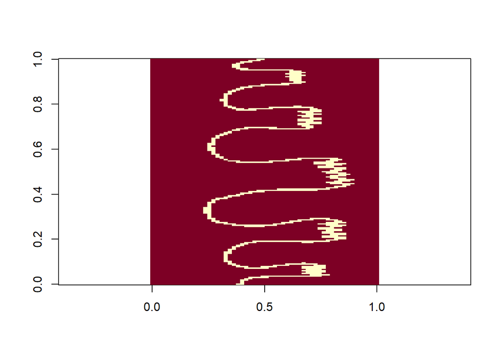

```r
image(ls_mat[[2]], asp=1)
```

If everything has worked out correctly, the list is then saved as an RData object for more direct loading in the future.

```r
save(ls_mat, file = "ls_mat.RData")
```

## Step 3 (R): Convert text images into matrices of semi-landmarks coordinates

Run second script, named 002_textimage2coordinates.R.

Load into R the Moore Neighbor Tracing function, and the list of matrices containing text images (see Step 2).

```r
source("./R/functions/Moore_NTA.R")

#-------------------------------------------------------------------------------
#Import R object containing images as text images.

load("./ls_mat.RData")
N_mat <- length(ls_mat)
```

Convert the text image matrices to x, y coordinates matrices of semi landmarks.

A couple parameters must be defined first:

```r
NLM <- 100 #Define number of landmarks to keep along line
prog <- F #Define if you want to see the algorithm in action
```

Increasing the NLM value will keep more details of the curves, at the cost of having more variables in future analyses.

Finally, run the function Moore.alg on the list of text image matrices.

```r
ls_coord <- list() #Initiate empty list

for (i in 1:N_mat) {
  ls_coord[[i]] <- Moore.alg(ls_mat[[i]], NLM = NLM, progress = prog)
}
```

The result is a list containing sublists with two matrices in each elements:

- the $o matrix contains all points along the curve
- the $subo matrix contains subsampled points (N = NLM).

To make it more easy to manipulate, and because all curves were subsampled as NLM points, it is possible to create an array containing only subsampled semilandmark coordinates matrices, and save it for easier loading in the future.

```r
arr_coords <- array(NA, dim = c(NLM, 2, N_mat))

for (i in 1:N_mat) {
  arr_coords[,,i] <- ls_coord[[i]]$subo
}

save(arr_coords, file = "arr_coords.RData")
```

## Step 4 (R): Some very simple analysis and plotting on these curves!

Run the third script, named 003_analyse_plots.R.

Load some functions and library:

```r
# Functions for Geometric Morphometrics (from J. Claude 2008 book)
source("R/functions/Rfunctions1.txt")

# Library for some plotting fun
library(grid)
```

Load the array of x,y coordinates (if not already in the environment).

```r
load("./arr_coords.RData")
```

Define the number of individuals (N) and number of landmarks (NLM), and apply Bookstein’s baseline alignment. This is a superimposition method (not Procrustes!!) based on first and last points, which are considered homologous in cephalopod sutures.

```r
N <- dim(arr_coords)[3]
NLM <- dim(arr_coords)[1]

aligned_lines <- booksteinA(arr_coords, 1, NLM)
#Bookstein baseline alignement
```

**Create a Figures subfolder to contain the plots.**

Plot the subsampled suture lines and save as a PDF.

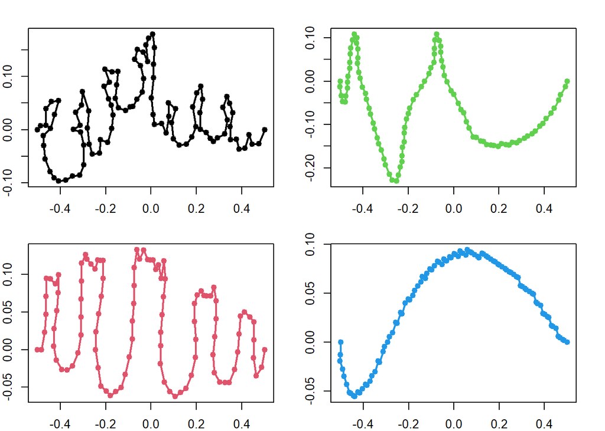

```r
pdf(file = "./Figures/split_panels.pdf", width = 5, height = 5)
layout(matrix(1:4, nrow = 2))
par(mar = c(2,2,2,2))
for (i in 1:N) {
  plot(aligned_lines[, 1, i],
       aligned_lines[, 2, i],
       pch=20,
       cex = 1.5,
       col = i)
  lines(aligned_lines[c(1:NLM, NA), 1, i],
        aligned_lines[c(1:NLM, NA), 2, i],
        lwd=2,
        col = i)
}
dev.off()
```

Do the same, with superimposed suture line curves

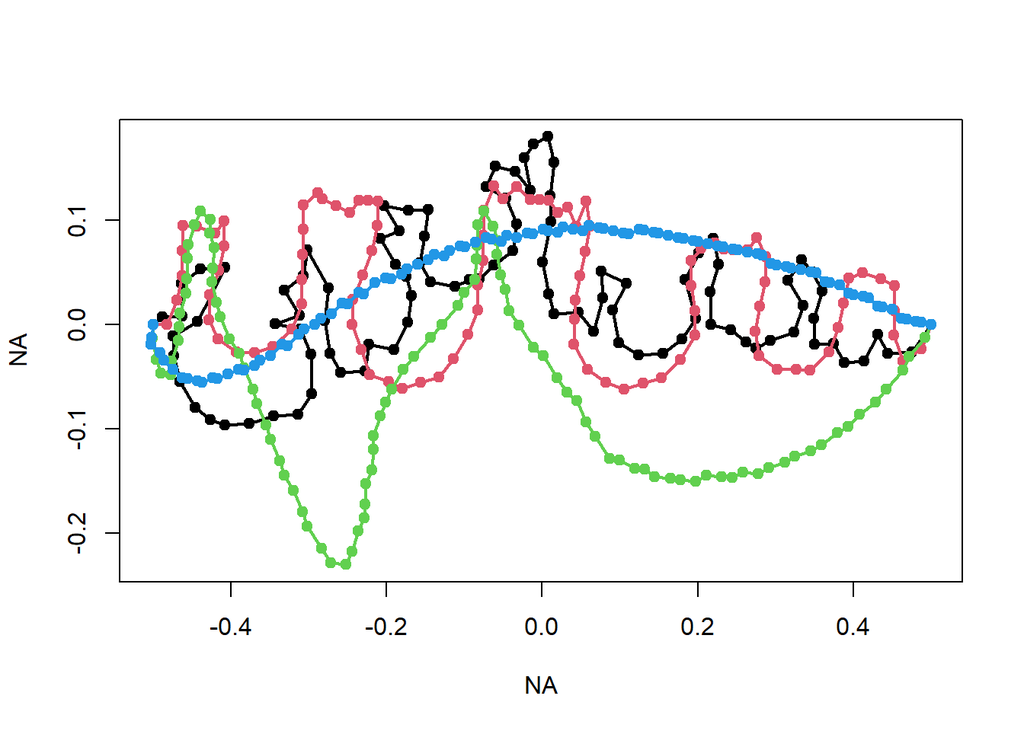

```r
pdf(file = "./Figures/superimposed.pdf", width = 5, height = 5)
plot(NA, NA,
     xlim = c(min(aligned_lines[,1,]), max(aligned_lines[,1,])),
     ylim = c(min(aligned_lines[,2,]), max(aligned_lines[,2,])))

for (i in 1:N) {
  points(aligned_lines[, 1, i],
       aligned_lines[, 2, i],
       pch=20,
       cex = 1.5,
       col = i)
  lines(aligned_lines[c(1:NLM, NA), 1, i],
        aligned_lines[c(1:NLM, NA), 2, i],
        lwd=2,
        col = i)
}
dev.off()
```

From these x,y coordinates we can make, for instance, a PCA.

```r
mat_coords <- matrix(NA, ncol = NLM*2, nrow = N)
#Initiate empty matrix for coordinates (indiv as rows, variables as columns)

for (i in 1:N) {
  mat_coords[i,] <- aligned_lines[,,i]
}

pca_lines <- prcomp(mat_coords)
```

And plot the first two axes of that morphospace.

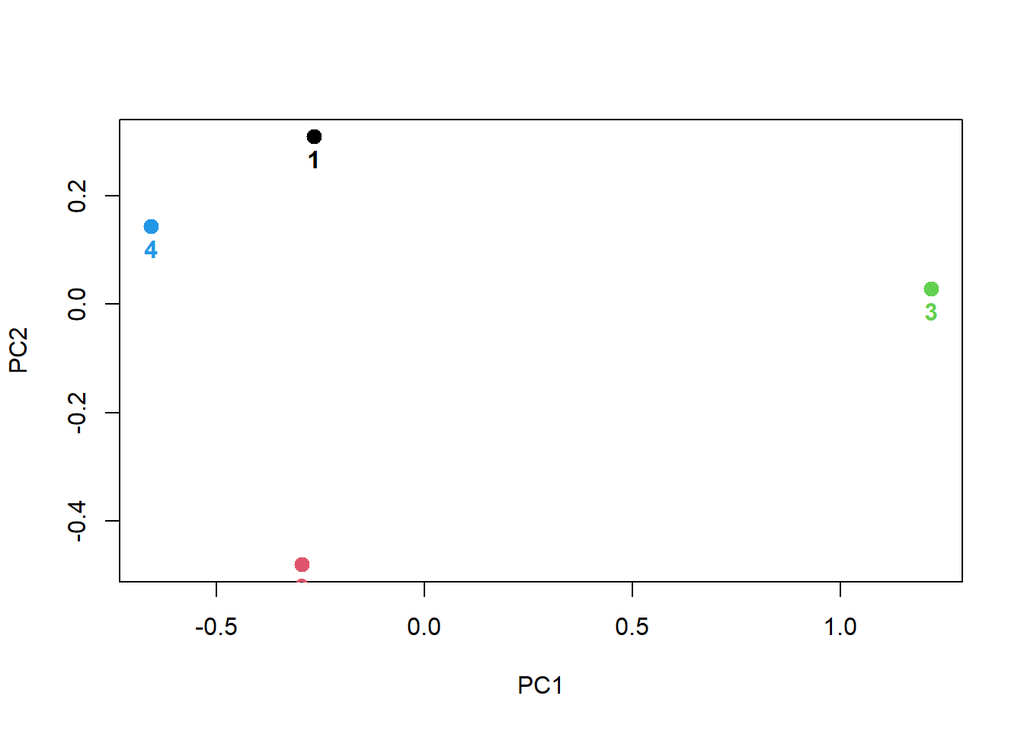

```r
plot(pca_lines$x[, 1:2],
     pch = 20,
     cex = 2,
     col = c(1:N))
text(pca_lines$x[, 1:2],
     labels = c(1:4),
     col = c(1:4),
     font = 2,
     pos = 1
     )
```

Finally, for a bit more fun, one can add subplots with the shapes, over the morphospace, with the following code. You will need to click in the plot area N times at the N positions in which you want the shapes to appear.

```r
plot(pca_lines$x[, 1:2],
     pch = 20,
     cex = 2,
     col = c(1:N))
text(pca_lines$x[, 1:2],
     labels = c(1:4),
     col = c(1:4),
     font = 2,
     pos = 1
     )

for (i in 1:N) { # Add subplots of line shapes within the plot

loc <- grid.locator(unit = "npc") #You'll have to click four times on the plot!
x <- loc$x
x <- as.numeric(gsub("npc", replacement = "", x=x))
y <- loc$y
y <- as.numeric(gsub("npc", replacement = "", x=y))

par(mfg = c(1,1), plt = c(x, x + 0.2, y, y + 0.1))

plot(aligned_lines[,,i],
     new = F,
     type = "l",
     col = i,
     xlab = "",
     ylab = "",
     axes = F)

}
```

Save that final plot.

```r
dev.copy2pdf(file = "./Figures/pca_with_shapes.pdf", out.type = "pdf")
```